# Padres Fumadores y la Salud de sus Hijos

Maximiliano Norbu

# Resumen

El siguiente estudio tiene como objetivo ver el impacto en la salud de un recién nacido el hecho de que su padre y/o madre hayan fumado durante el embarazo. Esto se hace comparando pesos de distintos bebés, cuyos padres en algunos casos no fumaron, en otros, fumaron poco y en el caso más extremo, llegaron a fumar hasta 50 cigarrillos diarios. El análisis comparativo se hará a través de estudios de correlaciones, regresiones simples y regresiones múltiples. Con estas buscaré comparar las variables relacionadas a fumar, con variables relacionadas al peso (y por ende, salud) del recién nacido. Espero lograr concluir si el cigarrillo tiene algún efecto riesgoso para la salud del bebé.

# Introducción

Tanto el peso como la estatura de un bebé al nacer son factores importantes que indican si este está sano o no. Lo habitual para los bebés es pesar alrededor de 3.5 kg. y medir alrededor de 50 cm. al nacer (aunque los hombres suelen pesar y medir un poco más). Si el peso y/o altura del recién nacido se alejaran demasiado de las medidas estándar, este puede ser más propenso a presentar problemas de salud. Es un conocimiento relativamente común que tanto las características del padre, como de la madre pueden afectar a las del hijo. También es lógico pensar que las semanas de gestación que haya tenido el feto pueden tener efecto en el desarrollo que este presente al nacer. Sin embargo, también se dice mucho que ciertos actos de la madre durante el embarazo pueden afectar la salud del infante. Estas pueden ir desde pintar la casa o estar mucho tiempo parada, hasta consumir algún tipo de drogas, estas drogas pudiendo ser legales como el café, el tabaco o el alcohol, o ilegales, como la marihuana o la heroína. Identificar apropiadamente las actividades perjudiciales es de suma importancia, pues estas pueden ser evitadas para prevenir riesgos de salud en el recién nacido.

Ahora bien, estas son aseveraciones sin mucha profundidad. Al escuchar una frase como “no debes tomar alcohol durante el embarazo”, se pueden presentar muchas dudas. Por ejemplo, si tomé un sorbo, ¿ya es suficiente para afectar al bebé?, ¿hay diferencia entre tomar un vaso de licor y, por ejemplo, tres vasos? No obstante, lo que más me llamó la atención fue el tema del tabaco, esto pues, es de las pocas sustancias que puede entrar al cuerpo de la madre sin que sea ella quien la está consumiendo (fumador pasivo).

Por esto decidí investigar para responder la pregunta, ¿Cuánto afecta al peso del recién nacido que el padre o la madre fumen durante el embarazo? Más específicamente, me gustaría encontrar una relación lineal entre el peso del recién nacido y la cantidad de cigarrillos consumida (por la madre y luego por el padre). Me gustaría saber la diferencia que hay si alguno de los padres fumador y si ninguno fuma; además de la diferencia entre padre fumador y madre fumadora. Finalmente, me interesa la diferencia entre padres que fuman poco y padres que fuman mucho.

Mi informe se organizará se la siguiente manera: primero se discutirá respecto a cuanto nos dice el peso del bebé respecto al riesgo de enfermedades. Esto pues, mi estudio busca ver cambios en el peligro de problemas a la salud del bebé respecto del uso del cigarrillo; sin embargo, la medida utilizadas es una medida físicas (peso) pues es más fácil y objetiva de medir. Segundo, hablaré de las características de mi base de datos, de qué modificaciones le haré y como se obtuvo. Luego, para el fuerte del estudio, haré las distintas regresiones lineales y mostraré los modelos que obtenga a partir de estas, incluyendo tanto las fórmulas como algunos gráficos para facilitar la visualización de los resultados. Finalmente, concluiré a partir de lo que logre observar de los distintos modelos lineales.

# Metodología

La base de datos presenta 17 variables, sin embargo yo he eliminado tres. Primero la variable “ID” pues no me interesa identificar individualmente cada caso, me interesa el estudio general. También eliminé la variable “LowBirthWeight” que es una variable que marcaba “low” si el peso del bebé era bajo y “normal” si era normal. Esta la he eliminado pues había otra variable que nos decía exactamente lo mismo, solo que en vez de emplear palabras, utilizaba números. Por último, he eliminado la variable “mage35” que es una variable que nos decía si la madre era mayor o menor de 35 años, esta la borré pues también hay una variable que es la edad de la madre, y al haber información “repetida”, podía entorpecer algún proceso de mi estudio, además, era información realmente no tomaré en cuenta en mi análisis.

La variable respuesta en la que basaré mi estudio es “Peso_Bajo_Bebé”, la cual es “0” si es normal para un bebé sano y “1” si es muy bajo. Por simplificación, utilizaré esta variable en las regresiones (y no el peso). Cabe recalcar que también utilizaré el término “índice de bajo peso” que se refiere a este último número. La manera en que usaré el término es que si el índice es alto (cercano a 1), quiere decir que el bebé es más propenso a tener bajo peso, mientras que si es pequeño, esta probabilidad es menor. La persona que obtuvo los datos es una estadística de la University of Sheffield llamada Ellen Marshall. Esta científica determinó que un recién nacido presenta bajo peso si este es menor a 6 lb. (o 2,7 kg. aproximadamente). También consideró que un alto peso no es un factor importante para determinar riesgo en la salud del infante, por lo que no hay una variable “Peso_Alto_Bebé”.

Para el estudio, las métodos estadísticos que utilizaré son correlaciones de las distintas variables respecto a mi variable de interés. Para esto, emplearé el comando “cor” de R. Esto lo haré con el objetivo de ver qué característica es la que se relaciona más al bajo peso del bebé y tener alguna guía para los pasos siguientes a seguir. Luego, basado en mis correlaciones, haré regresiones lineales simples, a través del comando “lm” de R. Mi objetivo con estas regresiones no es predecir si el bebé nacerá con bajo peso, si no, comparar que tanto afectan mis variables de interés al status de “Bajo Peso” del bebé. Finalmente, realizaré regresiones múltiples. Estas tomarán las distintas variables utilizadas en las regresiones simples y las combinarán en distintos modelos. Esto para ver si alguna característica “opaca” a otra. Esto lo veríamos reflejado en un coeficiente muy pequeño en alguna de las dos variables. Esto podría significar que una variable no es tan relevante cuando se toma una segunda variable en consideración. Este ultimo paso es muy importante pues es el que simula mejor la realidad y ve como se comportan las distintas variables, unas con otras.

# Resultados

Al hacer el estudio de correlaciones entre el “Peso_Bajo_Bebé” y las otras 13 variables, obtuve lo siguiente:

Correlaciones con la variable Peso Bajo Bebé

| Tabla 1 | Correlación |
| --- | --- |
| Circunferencia_Cabeza | -0.50024673 |
| Largo | -0.59224820 |
| Peso | -0.651804466 |
| Gestación | -0.60293498 |
| Madre_Fumadora | 0.25301216 |
| Edad_Madre | -0.076393724 |
| Cigarrillos_Madre | 0.035383657 |
| Altura_Madre | -0.20080064 |
| Peso_Madre | -0.33887910 |
| Edad_Padre | -0.24509537 |
| Años_Educación_Padre | -0.191273014 |
| Cigarrillos_Padre | 0.26601285 |
| Altura_Padre | 0.107236268 |
| Peso_Bajo_Bebé | 1.00000000 |

Aquí vemos algunas cosas bastante esperables, por ejemplo, que el peso bajo del bebé se relaciona de manera fuerte y negativa con la variable peso. Esto quiere decir que a mayor peso del bebé, menor índice de “bajo peso” presenta, lo cual es bastante intuitivo.

También, podemos ver que las únicas variables con correlación positiva son, Madre_Fumadora, Cigarrillos_Madre, Cigarrillos_Padre y Altura_Padre, que es, más o menos, lo que esperaba encontrar. Las primeras tres variables, son las variables que me interesaba estudiar, pues el objetivo de todo esto es ver como afecta el fumar al recién nacido. Los resultados obtenidos nos dicen que, sea pequeña o no, hay una relación entre el bajo peso y los cigarrillos fumados por el padre y la madre del bebé durante el embarazo. La otra variable con correlación positiva es “Altura_Padre”, sin embargo, no la utilizaré para este estudio.

Ahora, como las tres variables relacionadas con fumar tienen correlación positiva con el índice de bajo peso, decido modificar las variables “Cigarrillos_Padre” y “Cigarrillos_Madre”. Esto pues las entradas de estas dos variables iban desde 0 hasta 50 y no saldría una buena comparación con la variable “Madre_Fumadora”, pues esta última solo tiene entradas “0” y “1”. Por esto, escalo la cantidad de cigarrillos desde 0 a 50, hasta 0 a 1 (dividiendo por 50). También, he agregado una variable “Padre_Fumador” que funciona igual que la variable “Madre_Fumadora”. Esto, para tener más variables para trabajar y comparar.

La tabla 2 muestra los coeficientes de los modelos obtenidos de las regresiones lineales simples:

Coeficientes de la Regresión Simple de distintas variables con Bajo_Peso_Bebé

| Tabla 2 | Coeficiente |
| --- | --- |
| Madre_Fumadora | 0.2272727 |
| Padre_Fumador | 0.1851852 |
| Cigarrillos_Madre | 0.3102837 |
| Cigarrillos_Padre | 0.3442132 |

El gráfico 1 muestra una representación visual de los coeficientes de los modelos, en este podemos ver cuatro lineas que representan lo obtenido de las cuatro regresiones simples.

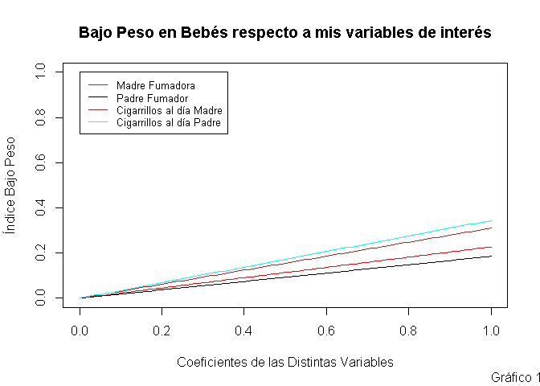

Notar que las regresiones las he hecho sin intercepto, esto, en un caso de querer predecir, le quitaría precisión a mi modelo. No obstante, como mi objetivo es comparar y no predecir, este formato me ayuda a observar mejor cuanto “peso” tiene cada variable de interés en el estado “Bajo_Peso”. De la tabla y el gráfico podemos extraer bastante información.

¿Qué puedo extraer de todo esto?

Ahora, las regresiones múltiples. He hecho tres modelos a través de regresión múltiple. El primero toma en cuenta si la madre es fumadora o no y cuantos cigarrillos al día fumó durante el embarazo. El segundo utiliza la información de si el padre fumó y cuantos cigarrillos diarios consumió durante la gestación de su hijo. El tercer y ultimo modelo, toma en consideración todas las variables de los anteriores dos modelos. En la siguiente tabla podemos observar los modelos obtenidos.

Coeficientes de los Modelos de Regresión Múltiple

| Tabla 3 | Madre_Fumadora | Cigarrillos_Madre | Padre_Fumador | Cigarrillos_Padre |
| --- | --- | --- | --- | --- |
| Modelo 1 | 0.387987 | -0.4464286 |  |  |
| Modelo 2 |  |  | 0.0050188 | 0.3368763 |
| Modelo 3 | 0.3252396 | -0.4617493 | -0.1001426 | 0.3129119 |

En la tabla 3 podemos ver que al tomar en consideración tanto la variable “Madre_Fumadora” como “Cigarrillos_Madre” (Modelo 1), los cigarrillos fumados por la madre, de hecho, tienen un coeficiente negativo. ¿Qué quiere decir esto? que en el caso de nuestros datos, una madre que fumaba 50 cigarrillo al día, era menos propensa a tener un bebé con bajo peso que una madre que fumaba 1. Lo cual es bastante curioso. Cabe recalcar que esta regresión es de suma importancia, pues siempre que la cantidad de cigarrillos diarios sea mayor a 0, la variable “Madre_Fumadora” será igual a 1. O sea, esta regresión es más realista que las anteriores pues no podemos separar estas dos características: van de la mano siempre. Para el caso del padre fumador (Modelo 2), vemos un caso contrario. Vemos que la característica de fumador, influencia muy poco en el índice de bajo peso, por otro lado, cada cigarrillo extra influye bastante. Para el caso del último modelo (que tiene las cuatro variables en consideración), vemos algo muy similar al de los casos anteriores, una madre fumadora aumenta el índice, mientras que una mayor cantidad de cigarrillos consumidos por esta, lo disminuye. Un padre fumador disminuye el índice, sin embargo, que consuma una gran cantidad de cigarrillos, lo aumenta. Información bastante interesante.

# Conclusiones

Lo primero que pudimos concluir es que hay una relación positiva entre la calidad de fumador de cualquiera de los dos padres y la condición de bajo peso del recién nacido. Lo segundo, que la cantidad de cigarrillos, también tiene una relación positiva con el índice de bajo peso.

Luego, vimos que al aislar las distintas variables de interés (condición de fumador y cantidad de cigarrillos diarios, en padre y madre), todas tenían en la práctica el mismo efecto. Estas aumentaban la probabilidad de que el hijo nazca con un peso riesgosamente bajo.

Sin embargo, cuando analizamos las cuatro variables juntas, vimos que cuando la madre ya era fumadora, el aumentar los cigarrillos diarios consumidos disminuía el índice de bajo peso. Para el padre vimos algo aun más interesante, cuando la madre ya era fumadora, el que el padre fuera fumador, disminuía levemente (de manera no muy significativa) el índice de bajo peso. Por otro lado, vimos que una alta cantidad de cigarrillos fumados por el padre sí aumenta el índice.

De todo esto puedo extraer que para evitar riesgos de salud en el bebé, lo mejor es que ambos padres dejen de fumar durante el periodo de gestación. No obstante, si la madre ya está fumando durante ese periodo, que el padre también fume, no es demasiado significativo. Ahora, si los padres ya decidieron seguir fumando durante el embarazo, es mejor que el padre mantenga una baja cantidad de cigarrillos, mientras que la madre debería aumentar esta cantidad.

# Referencias

[Link 1](https://www.urmc.rochester.edu/encyclopedia/content.aspx?contenttypeid=90&contentid=P02673)

[Link 2](https://www.uofmhealth.org/health-library/te6295#:~:text=The%20average%20birth%20weight%20for,usually%20lighter%20than%20later%20siblings.)

[Link 4](https://www.healthline.com/health/pregnancy/things-not-to-do-while-pregnant)

[Link 5](https://en.wikipedia.org/wiki/Passive_smoking)